# XGBoost in Python

In this notebook we will use **XGBoost** to build a collection of boosted trees, and use continuous and categorical data to predict **whether or not a customer will stop using a company's service** (Customer Churn).

**XGBoost** is an exceptionally useful machine learning method when you don't wanna sacrifice the ability to correctly classify observations but still want a model that is fairly easy to understand and interpret.

### Objectives for this notebook:

- Identifying and dealing with missing data
- Formatting the data for XGBoost
  1. splitting data into dependent and independent variables
  2. One-Hot Encoding
  3. Converting all columns to Int, Float or Bool
- Building a Preliminary XGBoost Model
- Optimizing parameters with cross validation and GridSearch
- Bulding, evaluation, drawing and interpreting the final XGBoost Model

#### Import the modules

```python
import pandas as pd
import numpy as np
import xgboost as xgb

from sklearn.model_selection import train_test_split # split data into training and testing sets
from sklearn.metrics import balanced_accuracy_score, roc_auc_score, make_scorer # for scoring
from sklearn.model_selection import GridSearchCV # for cross validation
from sklearn.metrics import confusion_matrix # create confusion matrix
from sklearn.metrics import plot_confusion_matrix # plots confusion matrix

!pwd
```

```
/home/goncalo/Desktop/ML/XGBoost
```

**Import the dataset**

https://www.kaggle.com/datasets/yeanzc/telco-customer-churn-ibm-dataset

```python
df = pd.read_csv('Telco_customer_churn.csv', sep=';')
print('The columns in the data file:')
print(df.columns)
print('The sample contains ' + str(len(df)) + ' sources')
df.head()
```

```
The columns in the data file:
Index(['CustomerID', 'Count', 'Country', 'State', 'City', 'Zip Code',
       'Lat Long', 'Latitude', 'Longitude', 'Gender', 'Senior Citizen',
       'Partner', 'Dependents', 'Tenure Months', 'Phone Service',
       'Multiple Lines', 'Internet Service', 'Online Security',
       'Online Backup', 'Device Protection', 'Tech Support', 'Streaming TV',
       'Streaming Movies', 'Contract', 'Paperless Billing', 'Payment Method',
       'Monthly Charges', 'Total Charges', 'Churn Label', 'Churn Value',
       'Churn Score', 'CLTV', 'Churn Reason'],
      dtype='object')
The sample contains 7043 sources
```

|  | CustomerID | Count | Country | State | City | Zip Code | Lat Long | Latitude | Longitude | Gender | ... | Contract | Paperless Billing | Payment Method | Monthly Charges | Total Charges | Churn Label | Churn Value | Churn Score | CLTV | Churn Reason |
| --- | --- | --- | --- | --- | --- | --- | --- | --- | --- | --- | --- | --- | --- | --- | --- | --- | --- | --- | --- | --- | --- |
| 0 | 3668-QPYBK | 1 | United States | California | Los Angeles | 90003 | 33.964131, -118.272783 | 33,964131 | -118,272783 | Male | ... | Month-to-month | Yes | Mailed check | 53,85 | 108,15 | Yes | 1 | 86 | 3239 | Competitor made better offer |
| 1 | 9237-HQITU | 1 | United States | California | Los Angeles | 90005 | 34.059281, -118.30742 | 34,059281 | -118,307420 | Female | ... | Month-to-month | Yes | Electronic check | 70,7 | 151,65 | Yes | 1 | 67 | 2701 | Moved |
| 2 | 9305-CDSKC | 1 | United States | California | Los Angeles | 90006 | 34.048013, -118.293953 | 34,048013 | -118,293953 | Female | ... | Month-to-month | Yes | Electronic check | 99,65 | 820,5 | Yes | 1 | 86 | 5372 | Moved |
| 3 | 7892-POOKP | 1 | United States | California | Los Angeles | 90010 | 34.062125, -118.315709 | 34,062125 | -118,315709 | Female | ... | Month-to-month | Yes | Electronic check | 104,8 | 3046,05 | Yes | 1 | 84 | 5003 | Moved |
| 4 | 0280-XJGEX | 1 | United States | California | Los Angeles | 90015 | 34.039224, -118.266293 | 34,039224 | -118,266293 | Male | ... | Month-to-month | Yes | Bank transfer (automatic) | 103,7 | 5036,3 | Yes | 1 | 89 | 5340 | Competitor had better devices |

5 rows × 33 columns

The last four variables contain exit interview information and should not be used for prediction to prevent data-leakage, so we will remove them:

```python
df.drop(['Churn Label','Churn Score', 'CLTV', 'Churn Reason'],
       axis = 1, inplace = True) # set axis = 0 to remove rows, axis = 1 to remove columns
                                 # inplace modifies and updates df
df.head()
```

|  | CustomerID | Count | Country | State | City | Zip Code | Lat Long | Latitude | Longitude | Gender | ... | Device Protection | Tech Support | Streaming TV | Streaming Movies | Contract | Paperless Billing | Payment Method | Monthly Charges | Total Charges | Churn Value |
| --- | --- | --- | --- | --- | --- | --- | --- | --- | --- | --- | --- | --- | --- | --- | --- | --- | --- | --- | --- | --- | --- |
| 0 | 3668-QPYBK | 1 | United States | California | Los Angeles | 90003 | 33.964131, -118.272783 | 33,964131 | -118,272783 | Male | ... | No | No | No | No | Month-to-month | Yes | Mailed check | 53,85 | 108,15 | 1 |
| 1 | 9237-HQITU | 1 | United States | California | Los Angeles | 90005 | 34.059281, -118.30742 | 34,059281 | -118,307420 | Female | ... | No | No | No | No | Month-to-month | Yes | Electronic check | 70,7 | 151,65 | 1 |
| 2 | 9305-CDSKC | 1 | United States | California | Los Angeles | 90006 | 34.048013, -118.293953 | 34,048013 | -118,293953 | Female | ... | Yes | No | Yes | Yes | Month-to-month | Yes | Electronic check | 99,65 | 820,5 | 1 |
| 3 | 7892-POOKP | 1 | United States | California | Los Angeles | 90010 | 34.062125, -118.315709 | 34,062125 | -118,315709 | Female | ... | Yes | Yes | Yes | Yes | Month-to-month | Yes | Electronic check | 104,8 | 3046,05 | 1 |
| 4 | 0280-XJGEX | 1 | United States | California | Los Angeles | 90015 | 34.039224, -118.266293 | 34,039224 | -118,266293 | Male | ... | Yes | No | Yes | Yes | Month-to-month | Yes | Bank transfer (automatic) | 103,7 | 5036,3 | 1 |

5 rows × 29 columns

Some of the other columns only contain a single value, and will not be useful for classification. For example:

```python
df['Count'].unique()
```

```
array([1])
```

```python
df['Country'].unique()
```

```
array(['United States'], dtype=object)
```

```python
df['State'].unique()
```

```
array(['California'], dtype=object)
```

Therefore all these columns are redundant to the model and we can omit these variables. Similarly, **CustomerID** can be removed since each row has a unique value. In contrast, **City** contains several limited values so it might be useful to aggregate and improve the model. Lastly, we will remove **Lat Long**, since there are different columns for Latitude and Longitude.

```python
df.drop(['CustomerID','Count','Country','State','Lat Long'],
       axis = 1, inplace=True)
df.head()
```

|  | City | Zip Code | Latitude | Longitude | Gender | Senior Citizen | Partner | Dependents | Tenure Months | Phone Service | ... | Device Protection | Tech Support | Streaming TV | Streaming Movies | Contract | Paperless Billing | Payment Method | Monthly Charges | Total Charges | Churn Value |
| --- | --- | --- | --- | --- | --- | --- | --- | --- | --- | --- | --- | --- | --- | --- | --- | --- | --- | --- | --- | --- | --- |
| 0 | Los Angeles | 90003 | 33,964131 | -118,272783 | Male | No | No | No | 2 | Yes | ... | No | No | No | No | Month-to-month | Yes | Mailed check | 53,85 | 108,15 | 1 |
| 1 | Los Angeles | 90005 | 34,059281 | -118,307420 | Female | No | No | Yes | 2 | Yes | ... | No | No | No | No | Month-to-month | Yes | Electronic check | 70,7 | 151,65 | 1 |
| 2 | Los Angeles | 90006 | 34,048013 | -118,293953 | Female | No | No | Yes | 8 | Yes | ... | Yes | No | Yes | Yes | Month-to-month | Yes | Electronic check | 99,65 | 820,5 | 1 |
| 3 | Los Angeles | 90010 | 34,062125 | -118,315709 | Female | No | Yes | Yes | 28 | Yes | ... | Yes | Yes | Yes | Yes | Month-to-month | Yes | Electronic check | 104,8 | 3046,05 | 1 |
| 4 | Los Angeles | 90015 | 34,039224 | -118,266293 | Male | No | No | Yes | 49 | Yes | ... | Yes | No | Yes | Yes | Month-to-month | Yes | Bank transfer (automatic) | 103,7 | 5036,3 | 1 |

5 rows × 24 columns

**NOTE:** Althought it is ok to have a blank space in the **City** for **XGBoost**, we can't have any whitespace if we want to draw a tree. So, to take care of that, we can replace the white splaces with **_**.

```python
df['City'].replace(' ', '_', regex = True, inplace=True)
df.head()
```

|  | City | Zip Code | Latitude | Longitude | Gender | Senior Citizen | Partner | Dependents | Tenure Months | Phone Service | ... | Device Protection | Tech Support | Streaming TV | Streaming Movies | Contract | Paperless Billing | Payment Method | Monthly Charges | Total Charges | Churn Value |
| --- | --- | --- | --- | --- | --- | --- | --- | --- | --- | --- | --- | --- | --- | --- | --- | --- | --- | --- | --- | --- | --- |
| 0 | Los_Angeles | 90003 | 33,964131 | -118,272783 | Male | No | No | No | 2 | Yes | ... | No | No | No | No | Month-to-month | Yes | Mailed check | 53,85 | 108,15 | 1 |
| 1 | Los_Angeles | 90005 | 34,059281 | -118,307420 | Female | No | No | Yes | 2 | Yes | ... | No | No | No | No | Month-to-month | Yes | Electronic check | 70,7 | 151,65 | 1 |
| 2 | Los_Angeles | 90006 | 34,048013 | -118,293953 | Female | No | No | Yes | 8 | Yes | ... | Yes | No | Yes | Yes | Month-to-month | Yes | Electronic check | 99,65 | 820,5 | 1 |
| 3 | Los_Angeles | 90010 | 34,062125 | -118,315709 | Female | No | Yes | Yes | 28 | Yes | ... | Yes | Yes | Yes | Yes | Month-to-month | Yes | Electronic check | 104,8 | 3046,05 | 1 |
| 4 | Los_Angeles | 90015 | 34,039224 | -118,266293 | Male | No | No | Yes | 49 | Yes | ... | Yes | No | Yes | Yes | Month-to-month | Yes | Bank transfer (automatic) | 103,7 | 5036,3 | 1 |

5 rows × 24 columns

```python
df['City'].unique()[0:10]
```

```
array(['Los_Angeles', 'Beverly_Hills', 'Huntington_Park', 'Lynwood',
       'Marina_Del_Rey', 'Inglewood', 'Santa_Monica', 'Torrance',
       'Whittier', 'La_Habra'], dtype=object)
```

We also need to eliminate the whitespace in the column names:

```python
df.columns = df.columns.str.replace(' ', '_')
df.head()
```

|  | City | Zip_Code | Latitude | Longitude | Gender | Senior_Citizen | Partner | Dependents | Tenure_Months | Phone_Service | ... | Device_Protection | Tech_Support | Streaming_TV | Streaming_Movies | Contract | Paperless_Billing | Payment_Method | Monthly_Charges | Total_Charges | Churn_Value |
| --- | --- | --- | --- | --- | --- | --- | --- | --- | --- | --- | --- | --- | --- | --- | --- | --- | --- | --- | --- | --- | --- |
| 0 | Los_Angeles | 90003 | 33,964131 | -118,272783 | Male | No | No | No | 2 | Yes | ... | No | No | No | No | Month-to-month | Yes | Mailed check | 53,85 | 108,15 | 1 |
| 1 | Los_Angeles | 90005 | 34,059281 | -118,307420 | Female | No | No | Yes | 2 | Yes | ... | No | No | No | No | Month-to-month | Yes | Electronic check | 70,7 | 151,65 | 1 |
| 2 | Los_Angeles | 90006 | 34,048013 | -118,293953 | Female | No | No | Yes | 8 | Yes | ... | Yes | No | Yes | Yes | Month-to-month | Yes | Electronic check | 99,65 | 820,5 | 1 |
| 3 | Los_Angeles | 90010 | 34,062125 | -118,315709 | Female | No | Yes | Yes | 28 | Yes | ... | Yes | Yes | Yes | Yes | Month-to-month | Yes | Electronic check | 104,8 | 3046,05 | 1 |
| 4 | Los_Angeles | 90015 | 34,039224 | -118,266293 | Male | No | No | Yes | 49 | Yes | ... | Yes | No | Yes | Yes | Month-to-month | Yes | Bank transfer (automatic) | 103,7 | 5036,3 | 1 |

5 rows × 24 columns

So far, we have removed all of the data that will not help us create an effective XGBoost model and reffomated the column names and city names so that we can draw a tree.

# A. Missing Data

## Part 1: Identifying Missing Data

One thing that is relatively unique about XGBoost is that it has default behavior for missing data. So all we have to do is identify missing values and make sure they are set to **0**.

First, let's see what sort of data is in each column:

```python
df.dtypes
```

```
City                 object
Zip_Code              int64
Latitude             object
Longitude            object
Gender               object
Senior_Citizen       object
Partner              object
Dependents           object
Tenure_Months         int64
Phone_Service        object
Multiple_Lines       object
Internet_Service     object
Online_Security      object
Online_Backup        object
Device_Protection    object
Tech_Support         object
Streaming_TV         object
Streaming_Movies     object
Contract             object
Paperless_Billing    object
Payment_Method       object
Monthly_Charges      object
Total_Charges        object
Churn_Value           int64
dtype: object
```

A lot of the columns are object, which is in agreement with what we see in the data, since when we ran head() there were a lot of text responses, like Yes and No. However, let's verify that we are getting what we expect:

```python
df['Phone_Service'].unique()
```

```
array(['Yes', 'No'], dtype=object)
```

So, **Phone_Service** has type object because it contains text, and it only contains two values, Yes and Now. There are no NA or '?', which is good. Now, we should verify every column but we will focus on one specific column that looks like it could be a problem: **Total_Charges**

If we look at the output from head(), **Total_Charges** looks like it contains numbers, not text, but the object datatype suggests that it contains more than just numbers:

```python
df['Total_Charges'].unique()
```

```
array(['108,15', '151,65', '820,5', ..., '7362,9', '346,45', '6844,5'],
      dtype=object)
```

```python
df['Total_Charges'].replace(',', '.', regex = True, inplace=True) # decimal number with . and not a comma
#df['Total_Charges'] = pd.to_numeric(df['Total_Charges']) # uncomment to see the error
```

```python
## Replace every decimal number with , to .
## If not, python doesn't recognize it as decimal number
df['Latitude'].replace(',', '.', regex = True, inplace=True) # decimal number with . and not a comma
df['Longitude'].replace(',', '.', regex = True, inplace=True) # decimal number with . and not a comma
df['Monthly_Charges'].replace(',', '.', regex = True, inplace=True) # decimal number with . and not a comma


## We also need to force the float type since by default it comes with object type
## And even if its just decimal numbers, XGBoost fit will not work with object type
df['Latitude'] = df['Latitude'].astype('float64')
df['Longitude'] = df['Longitude'].astype('float64')
df['Monthly_Charges'] = df['Monthly_Charges'].astype('float64')
```

```python
df.head()
```

|  | City | Zip_Code | Latitude | Longitude | Gender | Senior_Citizen | Partner | Dependents | Tenure_Months | Phone_Service | ... | Device_Protection | Tech_Support | Streaming_TV | Streaming_Movies | Contract | Paperless_Billing | Payment_Method | Monthly_Charges | Total_Charges | Churn_Value |
| --- | --- | --- | --- | --- | --- | --- | --- | --- | --- | --- | --- | --- | --- | --- | --- | --- | --- | --- | --- | --- | --- |
| 0 | Los_Angeles | 90003 | 33.964131 | -118.272783 | Male | No | No | No | 2 | Yes | ... | No | No | No | No | Month-to-month | Yes | Mailed check | 53.85 | 108.15 | 1 |
| 1 | Los_Angeles | 90005 | 34.059281 | -118.307420 | Female | No | No | Yes | 2 | Yes | ... | No | No | No | No | Month-to-month | Yes | Electronic check | 70.70 | 151.65 | 1 |
| 2 | Los_Angeles | 90006 | 34.048013 | -118.293953 | Female | No | No | Yes | 8 | Yes | ... | Yes | No | Yes | Yes | Month-to-month | Yes | Electronic check | 99.65 | 820.5 | 1 |
| 3 | Los_Angeles | 90010 | 34.062125 | -118.315709 | Female | No | Yes | Yes | 28 | Yes | ... | Yes | Yes | Yes | Yes | Month-to-month | Yes | Electronic check | 104.80 | 3046.05 | 1 |
| 4 | Los_Angeles | 90015 | 34.039224 | -118.266293 | Male | No | No | Yes | 49 | Yes | ... | Yes | No | Yes | Yes | Month-to-month | Yes | Bank transfer (automatic) | 103.70 | 5036.3 | 1 |

5 rows × 24 columns

```python
df.dtypes
```

```
City                  object
Zip_Code               int64
Latitude             float64
Longitude            float64
Gender                object
Senior_Citizen        object
Partner               object
Dependents            object
Tenure_Months          int64
Phone_Service         object
Multiple_Lines        object
Internet_Service      object
Online_Security       object
Online_Backup         object
Device_Protection     object
Tech_Support          object
Streaming_TV          object
Streaming_Movies      object
Contract              object
Paperless_Billing     object
Payment_Method        object
Monthly_Charges      float64
Total_Charges         object
Churn_Value            int64
dtype: object
```

## Part 2: Dealing with Missing Data

One thing that is relatively unique about XGBoost is that it determines default behavior for missing data. So all we want to do is identify missing values and make sure they are set to **0**.

However, before we do that, let's see how many rows are missing data. If it's a lot, then we might have a problem on our hands that is bigger than what **XGBoost** can deal on its own. If it's not that many, we can just set them to **0**.

```python
len(df.loc[df['Total_Charges'] == ' '])
```

```
11
```

```python
df.loc[df['Total_Charges'] == ' ']
```

|  | City | Zip_Code | Latitude | Longitude | Gender | Senior_Citizen | Partner | Dependents | Tenure_Months | Phone_Service | ... | Device_Protection | Tech_Support | Streaming_TV | Streaming_Movies | Contract | Paperless_Billing | Payment_Method | Monthly_Charges | Total_Charges | Churn_Value |
| --- | --- | --- | --- | --- | --- | --- | --- | --- | --- | --- | --- | --- | --- | --- | --- | --- | --- | --- | --- | --- | --- |
| 2234 | San_Bernardino | 92408 | 34.084909 | -117.258107 | Female | No | Yes | No | 0 | No | ... | Yes | Yes | Yes | No | Two year | Yes | Bank transfer (automatic) | 52.55 |  | 0 |
| 2438 | Independence | 93526 | 36.869584 | -118.189241 | Male | No | No | No | 0 | Yes | ... | No internet service | No internet service | No internet service | No internet service | Two year | No | Mailed check | 20.25 |  | 0 |
| 2568 | San_Mateo | 94401 | 37.590421 | -122.306467 | Female | No | Yes | No | 0 | Yes | ... | Yes | No | Yes | Yes | Two year | No | Mailed check | 80.85 |  | 0 |
| 2667 | Cupertino | 95014 | 37.306612 | -122.080621 | Male | No | Yes | Yes | 0 | Yes | ... | No internet service | No internet service | No internet service | No internet service | Two year | No | Mailed check | 25.75 |  | 0 |
| 2856 | Redcrest | 95569 | 40.363446 | -123.835041 | Female | No | Yes | No | 0 | No | ... | Yes | Yes | Yes | No | Two year | No | Credit card (automatic) | 56.05 |  | 0 |
| 4331 | Los_Angeles | 90029 | 34.089953 | -118.294824 | Male | No | Yes | Yes | 0 | Yes | ... | No internet service | No internet service | No internet service | No internet service | Two year | No | Mailed check | 19.85 |  | 0 |
| 4687 | Sun_City | 92585 | 33.739412 | -117.173334 | Male | No | Yes | Yes | 0 | Yes | ... | No internet service | No internet service | No internet service | No internet service | Two year | No | Mailed check | 25.35 |  | 0 |
| 5104 | Ben_Lomond | 95005 | 37.078873 | -122.090386 | Female | No | Yes | Yes | 0 | Yes | ... | No internet service | No internet service | No internet service | No internet service | Two year | No | Mailed check | 20.00 |  | 0 |
| 5719 | La_Verne | 91750 | 34.144703 | -117.770299 | Male | No | Yes | Yes | 0 | Yes | ... | No internet service | No internet service | No internet service | No internet service | One year | Yes | Mailed check | 19.70 |  | 0 |
| 6772 | Bell | 90201 | 33.970343 | -118.171368 | Female | No | Yes | Yes | 0 | Yes | ... | Yes | Yes | Yes | No | Two year | No | Mailed check | 73.35 |  | 0 |
| 6840 | Wilmington | 90744 | 33.782068 | -118.262263 | Male | No | No | Yes | 0 | Yes | ... | No | Yes | No | No | Two year | Yes | Bank transfer (automatic) | 61.90 |  | 0 |

11 rows × 24 columns

We see that all 11 people with **Total_Charges == ' '** have just signed up, because **Tenure_Months** is 0. All these people also have **Churn_Value** set to 0, because they just signed up. Since the number of people is small, we will try setting Total_Charges to 0, rather than removing the entire rows.

```python
df.loc[(df['Total_Charges'] == ' '), 'Total_Charges'] = 0
```

Now let's verify that we modified Total Charges correctly by looking at everyone who had Tenure Months set to 0.

```python
df.loc[df['Tenure_Months'] == 0]
```

|  | City | Zip_Code | Latitude | Longitude | Gender | Senior_Citizen | Partner | Dependents | Tenure_Months | Phone_Service | ... | Device_Protection | Tech_Support | Streaming_TV | Streaming_Movies | Contract | Paperless_Billing | Payment_Method | Monthly_Charges | Total_Charges | Churn_Value |
| --- | --- | --- | --- | --- | --- | --- | --- | --- | --- | --- | --- | --- | --- | --- | --- | --- | --- | --- | --- | --- | --- |
| 2234 | San_Bernardino | 92408 | 34.084909 | -117.258107 | Female | No | Yes | No | 0 | No | ... | Yes | Yes | Yes | No | Two year | Yes | Bank transfer (automatic) | 52.55 | 0 | 0 |
| 2438 | Independence | 93526 | 36.869584 | -118.189241 | Male | No | No | No | 0 | Yes | ... | No internet service | No internet service | No internet service | No internet service | Two year | No | Mailed check | 20.25 | 0 | 0 |
| 2568 | San_Mateo | 94401 | 37.590421 | -122.306467 | Female | No | Yes | No | 0 | Yes | ... | Yes | No | Yes | Yes | Two year | No | Mailed check | 80.85 | 0 | 0 |
| 2667 | Cupertino | 95014 | 37.306612 | -122.080621 | Male | No | Yes | Yes | 0 | Yes | ... | No internet service | No internet service | No internet service | No internet service | Two year | No | Mailed check | 25.75 | 0 | 0 |
| 2856 | Redcrest | 95569 | 40.363446 | -123.835041 | Female | No | Yes | No | 0 | No | ... | Yes | Yes | Yes | No | Two year | No | Credit card (automatic) | 56.05 | 0 | 0 |
| 4331 | Los_Angeles | 90029 | 34.089953 | -118.294824 | Male | No | Yes | Yes | 0 | Yes | ... | No internet service | No internet service | No internet service | No internet service | Two year | No | Mailed check | 19.85 | 0 | 0 |
| 4687 | Sun_City | 92585 | 33.739412 | -117.173334 | Male | No | Yes | Yes | 0 | Yes | ... | No internet service | No internet service | No internet service | No internet service | Two year | No | Mailed check | 25.35 | 0 | 0 |
| 5104 | Ben_Lomond | 95005 | 37.078873 | -122.090386 | Female | No | Yes | Yes | 0 | Yes | ... | No internet service | No internet service | No internet service | No internet service | Two year | No | Mailed check | 20.00 | 0 | 0 |
| 5719 | La_Verne | 91750 | 34.144703 | -117.770299 | Male | No | Yes | Yes | 0 | Yes | ... | No internet service | No internet service | No internet service | No internet service | One year | Yes | Mailed check | 19.70 | 0 | 0 |
| 6772 | Bell | 90201 | 33.970343 | -118.171368 | Female | No | Yes | Yes | 0 | Yes | ... | Yes | Yes | Yes | No | Two year | No | Mailed check | 73.35 | 0 | 0 |
| 6840 | Wilmington | 90744 | 33.782068 | -118.262263 | Male | No | No | Yes | 0 | Yes | ... | No | Yes | No | No | Two year | Yes | Bank transfer (automatic) | 61.90 | 0 | 0 |

11 rows × 24 columns

And we see that df contains 0s instead of ' 's for missing values.

**NOTE:** Total_Charges still has the object data type. Since XGBoost only allows int, float or boolean data types, we need to convert it to numeric:

```python
df['Total_Charges'] = pd.to_numeric(df['Total_Charges'])
df.dtypes
```

```
City                  object
Zip_Code               int64
Latitude             float64
Longitude            float64
Gender                object
Senior_Citizen        object
Partner               object
Dependents            object
Tenure_Months          int64
Phone_Service         object
Multiple_Lines        object
Internet_Service      object
Online_Security       object
Online_Backup         object
Device_Protection     object
Tech_Support          object
Streaming_TV          object
Streaming_Movies      object
Contract              object
Paperless_Billing     object
Payment_Method        object
Monthly_Charges      float64
Total_Charges        float64
Churn_Value            int64
dtype: object
```

Now that we have dealt with the missing data, we will replace all of the other whitespaces in all of the columns with underscores. Check **Contract** and **Payment_Method** columns.

**NOTE:** We are doing this so we can draw a picture of one of the XGBoost Trees.

```python
df.replace(' ', '_', regex=True, inplace=True)
df.head()
```

|  | City | Zip_Code | Latitude | Longitude | Gender | Senior_Citizen | Partner | Dependents | Tenure_Months | Phone_Service | ... | Device_Protection | Tech_Support | Streaming_TV | Streaming_Movies | Contract | Paperless_Billing | Payment_Method | Monthly_Charges | Total_Charges | Churn_Value |
| --- | --- | --- | --- | --- | --- | --- | --- | --- | --- | --- | --- | --- | --- | --- | --- | --- | --- | --- | --- | --- | --- |
| 0 | Los_Angeles | 90003 | 33.964131 | -118.272783 | Male | No | No | No | 2 | Yes | ... | No | No | No | No | Month-to-month | Yes | Mailed_check | 53.85 | 108.15 | 1 |
| 1 | Los_Angeles | 90005 | 34.059281 | -118.307420 | Female | No | No | Yes | 2 | Yes | ... | No | No | No | No | Month-to-month | Yes | Electronic_check | 70.70 | 151.65 | 1 |
| 2 | Los_Angeles | 90006 | 34.048013 | -118.293953 | Female | No | No | Yes | 8 | Yes | ... | Yes | No | Yes | Yes | Month-to-month | Yes | Electronic_check | 99.65 | 820.50 | 1 |
| 3 | Los_Angeles | 90010 | 34.062125 | -118.315709 | Female | No | Yes | Yes | 28 | Yes | ... | Yes | Yes | Yes | Yes | Month-to-month | Yes | Electronic_check | 104.80 | 3046.05 | 1 |
| 4 | Los_Angeles | 90015 | 34.039224 | -118.266293 | Male | No | No | Yes | 49 | Yes | ... | Yes | No | Yes | Yes | Month-to-month | Yes | Bank_transfer_(automatic) | 103.70 | 5036.30 | 1 |

5 rows × 24 columns

# B. Format Data

## Part 1: Split the Data into Dependent and Independent Variables

**Now that we have taken care of the missing data, we are ready to start formatting the data for making a XGBoost Model**

The first step is to split the data into two parts:

1. The columns of data that we will use to make classifications - We call this **X**
2. The columns of data that we want to predict - We call this **y**

**In this case, we want to predict Churn Value (whether or not someone will leave the company).**

**NOTE:** The reason we deal with missing data before splitting into **X** and **y** is that if we need to remove rows, splitting after ensures that each row in **X** corresponds with the appropriate value in **y**.

```python
X = df.drop('Churn_Value', axis = 1).copy()
X.head()
```

|  | City | Zip_Code | Latitude | Longitude | Gender | Senior_Citizen | Partner | Dependents | Tenure_Months | Phone_Service | ... | Online_Backup | Device_Protection | Tech_Support | Streaming_TV | Streaming_Movies | Contract | Paperless_Billing | Payment_Method | Monthly_Charges | Total_Charges |
| --- | --- | --- | --- | --- | --- | --- | --- | --- | --- | --- | --- | --- | --- | --- | --- | --- | --- | --- | --- | --- | --- |
| 0 | Los_Angeles | 90003 | 33.964131 | -118.272783 | Male | No | No | No | 2 | Yes | ... | Yes | No | No | No | No | Month-to-month | Yes | Mailed_check | 53.85 | 108.15 |
| 1 | Los_Angeles | 90005 | 34.059281 | -118.307420 | Female | No | No | Yes | 2 | Yes | ... | No | No | No | No | No | Month-to-month | Yes | Electronic_check | 70.70 | 151.65 |
| 2 | Los_Angeles | 90006 | 34.048013 | -118.293953 | Female | No | No | Yes | 8 | Yes | ... | No | Yes | No | Yes | Yes | Month-to-month | Yes | Electronic_check | 99.65 | 820.50 |
| 3 | Los_Angeles | 90010 | 34.062125 | -118.315709 | Female | No | Yes | Yes | 28 | Yes | ... | No | Yes | Yes | Yes | Yes | Month-to-month | Yes | Electronic_check | 104.80 | 3046.05 |
| 4 | Los_Angeles | 90015 | 34.039224 | -118.266293 | Male | No | No | Yes | 49 | Yes | ... | Yes | Yes | No | Yes | Yes | Month-to-month | Yes | Bank_transfer_(automatic) | 103.70 | 5036.30 |

5 rows × 23 columns

```python
y = df['Churn_Value'].copy()
y.head()
```

```
0    1
1    1
2    1
3    1
4    1
Name: Churn_Value, dtype: int64
```

Now that we have created X, which is the data we want to use to make predictions, and y, which has the data we want to predict, we are ready to continue formatting X so that it is suitable for making a model **XGBoost**.

## Part 2: One-Hot Encoding

Now that we have split the data frame into X and y, we need to take a closer look at the variables in X and see what each variable represents and the type of data (float or categorical) it should contain:

- **City - Category**
  - Los Angeles, Beverly Hills, etc.
- **Zip Code - Category**
  - 90003, 90005, etc..
- **Latitude - Float**
- **Longitude - Float**
- **Gender - Category**
  - Female, Male
- **Senior Citizen - Category**
  - Yes, No
- **Partner - Category**
  - Yes, No
- **Dependents - Category**
- **Tenure Months - Float**
- **Phone Service - Category**
  - Yes, No
- **Multiple Lines - Category**
  - Yes, No
- **Internet Service - Category**
  - No, DSL, Fiber optic
- **Online Security - Category**
  - Yes, No
- **Online Backup - Category**
  - Yes, No
- **Device Protection - Category**
  - Yes, No
- **Tech Support - Category**
  - Yes, No
- **Streaming TV - Category**
  - Yes, No
- **Streaming Movies - Category**
  - Yes, No
- **Contract - Category**
  - Month-to-month, One year, Two years
- **Payment Method - Category**
  - Mailed check, ELetronic check, etc..
- **Monthly Charges - Float**
- **Total Charges - Float**

Now, jus tto review, let's look at the data types in X to remember how python is seeing the data right now.

```python
X.dtypes
```

```
City                  object
Zip_Code               int64
Latitude             float64
Longitude            float64
Gender                object
Senior_Citizen        object
Partner               object
Dependents            object
Tenure_Months          int64
Phone_Service         object
Multiple_Lines        object
Internet_Service      object
Online_Security       object
Online_Backup         object
Device_Protection     object
Tech_Support          object
Streaming_TV          object
Streaming_Movies      object
Contract              object
Paperless_Billing     object
Payment_Method        object
Monthly_Charges      float64
Total_Charges        float64
dtype: object
```

So, we see that **Latitude, Longitude, Monthly_Charges** and **Total_Charges** are all float64, which is good, since we want them to be floating point numbers. All of the columns that are object type, however, need to be inspected to make sure they only contain reasonable models, and most, if not all of them, will need to change. This is because, while XGBoost natively suppots continuous data, like **Monthtly_Charges** and **Total_Charges**, it does not natively support categorical data, like **Phone_Service** which contains 2 different categories. Thus, in order to use categorical data with XGBoost, we have to convert all columns with categorical data into columns of binary values, using **One-Hot Encoding**.

To see what would be wrong with treating categorical data like continuous data, let's look at an example with the **Payment_Method** column:

```
1. Mailed_Check
2. Eletronic_Check
3. Bank_Transfer
4. Credit_Card
```

If we converted these categories to numbers, 1,2, 3 and 4, and treated them like continuous data, then we would assume that 4 is more similar to 3, than it is to 1 or 2, which are other forms of payment. That means that the XGBoost tree would be more likely to cluster the people with 4s and 3s together than the people with 4s and 1s together. In contrast, if we treated these Payment_Methods like categorical data, then we treat each one as a separate category that is no more or less similar to any of the other categories. Thus, the likelihood of clustering people wh pay with a Mailed_Check with people who pay with Eletronic_Check is the same as clustering Mailed_Check with Credit_Card, and that approach is more reasonable.

**NOTE**: There are many different ways to do **One-Hot Encoding** in Python. Two of the more popular methods are:

- ColumnTransformer() from Scikit-learn - more commonly used in production systems and has more features
- get_dummies() from Pandas - easiest to do and easier to verify that it worked as intended

First, before we commit to converting cp with **One-Hot Encoding**, let's just just see what happens when we convert solely **Payment_Method** without saving the results:

```python
pd.get_dummies(X, columns = ['Payment_Method']).head()
```

|  | City | Zip_Code | Latitude | Longitude | Gender | Senior_Citizen | Partner | Dependents | Tenure_Months | Phone_Service | ... | Streaming_TV | Streaming_Movies | Contract | Paperless_Billing | Monthly_Charges | Total_Charges | Payment_Method_Bank_transfer_(automatic) | Payment_Method_Credit_card_(automatic) | Payment_Method_Electronic_check | Payment_Method_Mailed_check |
| --- | --- | --- | --- | --- | --- | --- | --- | --- | --- | --- | --- | --- | --- | --- | --- | --- | --- | --- | --- | --- | --- |
| 0 | Los_Angeles | 90003 | 33.964131 | -118.272783 | Male | No | No | No | 2 | Yes | ... | No | No | Month-to-month | Yes | 53.85 | 108.15 | 0 | 0 | 0 | 1 |
| 1 | Los_Angeles | 90005 | 34.059281 | -118.307420 | Female | No | No | Yes | 2 | Yes | ... | No | No | Month-to-month | Yes | 70.70 | 151.65 | 0 | 0 | 1 | 0 |
| 2 | Los_Angeles | 90006 | 34.048013 | -118.293953 | Female | No | No | Yes | 8 | Yes | ... | Yes | Yes | Month-to-month | Yes | 99.65 | 820.50 | 0 | 0 | 1 | 0 |
| 3 | Los_Angeles | 90010 | 34.062125 | -118.315709 | Female | No | Yes | Yes | 28 | Yes | ... | Yes | Yes | Month-to-month | Yes | 104.80 | 3046.05 | 0 | 0 | 1 | 0 |
| 4 | Los_Angeles | 90015 | 34.039224 | -118.266293 | Male | No | No | Yes | 49 | Yes | ... | Yes | Yes | Month-to-month | Yes | 103.70 | 5036.30 | 1 | 0 | 0 | 0 |

5 rows × 26 columns

```python
X_encoded = pd.get_dummies(X, columns=['City',
                                      'Gender',
                                      'Senior_Citizen',
                                      'Partner',
                                      'Dependents',
                                      'Phone_Service',
                                      'Multiple_Lines',
                                      'Internet_Service',
                                      'Online_Security',
                                      'Online_Backup',
                                      'Device_Protection',
                                      'Tech_Support',
                                      'Streaming_TV',
                                      'Streaming_Movies',
                                      'Contract',
                                      'Paperless_Billing',
                                      'Payment_Method'])
X_encoded.head()
```

|  | Zip_Code | Latitude | Longitude | Tenure_Months | Monthly_Charges | Total_Charges | City_Acampo | City_Acton | City_Adelanto | City_Adin | ... | Streaming_Movies_Yes | Contract_Month-to-month | Contract_One_year | Contract_Two_year | Paperless_Billing_No | Paperless_Billing_Yes | Payment_Method_Bank_transfer_(automatic) | Payment_Method_Credit_card_(automatic) | Payment_Method_Electronic_check | Payment_Method_Mailed_check |
| --- | --- | --- | --- | --- | --- | --- | --- | --- | --- | --- | --- | --- | --- | --- | --- | --- | --- | --- | --- | --- | --- |
| 0 | 90003 | 33.964131 | -118.272783 | 2 | 53.85 | 108.15 | 0 | 0 | 0 | 0 | ... | 0 | 1 | 0 | 0 | 0 | 1 | 0 | 0 | 0 | 1 |
| 1 | 90005 | 34.059281 | -118.307420 | 2 | 70.70 | 151.65 | 0 | 0 | 0 | 0 | ... | 0 | 1 | 0 | 0 | 0 | 1 | 0 | 0 | 1 | 0 |
| 2 | 90006 | 34.048013 | -118.293953 | 8 | 99.65 | 820.50 | 0 | 0 | 0 | 0 | ... | 1 | 1 | 0 | 0 | 0 | 1 | 0 | 0 | 1 | 0 |
| 3 | 90010 | 34.062125 | -118.315709 | 28 | 104.80 | 3046.05 | 0 | 0 | 0 | 0 | ... | 1 | 1 | 0 | 0 | 0 | 1 | 0 | 0 | 1 | 0 |
| 4 | 90015 | 34.039224 | -118.266293 | 49 | 103.70 | 5036.30 | 0 | 0 | 0 | 0 | ... | 1 | 1 | 0 | 0 | 0 | 1 | 1 | 0 | 0 | 0 |

5 rows × 1178 columns

Now, one last thing before we build an XGBoost model. Let's verify that y only contains 1s and 0s with unique():

```python
y.unique()
```

```
array([1, 0])
```

# C. Build a preliminary XGBoost model

Now that the data is correctly formatted for making an XGBoost model, we simply need to split the data into trainign and testing sets and build the model. However, first, let's observe that this data is imbalanced by dividing the number of people who left the company (y = 1), by the total number of people in the dataset.

```python
sum(y)/len(y)
```

```
0.2653698707936959
```

So we see that only 27% of the people in the dataset left the company. Because of this, when we split the data into training and datasets, we will split using stratification in order to maintain the same percentage of people who left the company in both the training and testing sets.

```python
X_train, X_test, y_train, y_test = train_test_split(X_encoded, y, random_state = 42, stratify = y)
```

Now let's verify that using stratify worked as intended

```python
print(sum(y_train)/len(y_train))
print(sum(y_test)/len(y_test))
```

```
0.2654297614539947
0.26519023282226006
```

Both sets hae the same percentage of people that left the company. Now we can finally build the preliminary model.

**NOTE:** Instead of determining the optimal number of trees with cross validation, we will use **early stopping** to stop building trees when they no longer improve the situation.

```python
## objective = binary:logistic is for classification
## missing = None -> tells XGBoost that 0s stands for missing values # this raises a missing/null value problem
clf_xgb = xgb.XGBClassifier(objective = 'binary:logistic', seed = 42) # create XGBoost instance

clf_xgb.fit(X_train,
           y_train,
           verbose = True,
           early_stopping_rounds = 10,
           eval_metric = 'aucpr', # we evaluate using auc
           eval_set=[(X_test, y_test)]) # it evaluates on the testing datasets
```

```
XGBClassifier(base_score=0.5, booster='gbtree', colsample_bylevel=1,
              colsample_bynode=1, colsample_bytree=1, enable_categorical=False,
              gamma=0, gpu_id=-1, importance_type=None,
              interaction_constraints='', learning_rate=0.300000012,
              max_delta_step=0, max_depth=6, min_child_weight=1, missing=nan,
              monotone_constraints='()', n_estimators=100, n_jobs=8,
              num_parallel_tree=1, predictor='auto', random_state=42,
              reg_alpha=0, reg_lambda=1, scale_pos_weight=1, seed=42,
              subsample=1, tree_method='exact', validate_parameters=1,
              verbosity=None)
```

Now that we have built an **XGBoost** model for classification, let's see how it performs on the Testing Dataset by running the testing dataset down the model and drawing a confusion Matrix:

```
<sklearn.metrics._plot.confusion_matrix.ConfusionMatrixDisplay at 0x7f1482258ca0>
```

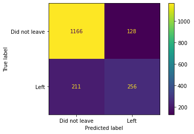

```python
plot_confusion_matrix(clf_xgb,
                    X_test,
                    y_test,
                    values_format='d',
                    display_labels=['Did not leave','Left'])
```

We see that of 1294 people that did not leave the company, 1166 (90%) were correctly classified and that of the 467 people that defaulted, 256 (55%) were correctly classified. Now let's attempt to do better.

Part of the problem is that our data is imbalanced, which we saw earlier and we see this in the confusion matrix with the top row showing 1294 people that did not leave the company and the bottom row showing 467 that did. Because people leaving costs the company a lot of money, we would like to capture more of the people that left. The good news is that **XGBoost** has a parameter, **scale_pos_weight** that helps with imbalanced data. So, in order to improve the predictions, let's use cross validations to optimize the parameters.

# D. Optimize Parameters with Cross Validation and GridSearchCV()

**XGBoost** has a lot of hyperparameters, parameters that we have to manually configure and are not determined by the model itself, including **max_depth**, the maximum tree depth, **learning_rate**, the learning rate or 'eta', **gamma**, the parameter that encourages pruning, and **reg_lambda**, the regularization parameter lambda.

Since we have multiple hyperparameters to optimize, we will use **GridSearchCV()** and we specify several potential values for the hyperparameters and the function will test all possible combinations and output the best combination.

```python
## When the data are imbalanced the XGBoost documentation says that if you only care about
## the overall perfomance metric (AUC) of your prediction
##     * Balance the positive and negative weights via scale_pos_weight
##     * Use AUC for evaluation
## Note: We run GridSearchCV() sequentially on subsets of parameters options, rather than
## all in order to optimize parametersin a short period of time

param_grid = {
    'max_dept': [3,4,5],
    'learning_rate': [0.1, 0.01, 0.05],
    'gamma': [0, 0.25, 1.0],
    'reg_lambda': [0, 1.0, 10.0],
    'scale_pos_weight': [1, 3, 5] # XGBoost recommends sum(negative instances) / sum(positive instances)
}

## To speed up cross validation and to further prevent overfitting, we are only using
## a random subset of the data (90%) and are only using a random subset of the features
## (columns), 50% per tree.
optimal_params = GridSearchCV(
    estimator= xgb.XGBClassifier(objective='binary:logistic',
                                seed=42,
                                subsample=0.9, # random subset of 90% of the overall data
                                colsample_bytree=0.5, # select 50% of features
                                use_label_encoder=False), # disable warnings
    param_grid = param_grid,
    scoring='roc_auc',
    verbose = 0,
    n_jobs = 10,
    cv = 3
)

optimal_params.fit(X_train,
                  y_train,
                  early_stopping_rounds=10,
                  eval_metric = 'auc',
                  eval_set = [(X_test,y_test)],
                  verbose = False)

print(optimal_params.best_params_)
```

[output not shown]